# Movie Recommendation Engine

### Sylvia Lee

### Unsupervised Learning Capstone Project

# Purpose of Study

Build a content-based recommendation engine that helps Netflix identify similar movies to users based on movie characteristics.

# The Data

- Contains metadata for 4,803 movies listed in TMDb movie database
- Consists of movies released on or before July 2017
- Information includes cast, crew, plot keywords, budget, revenue, posters, release dates, languages, production companies, countries, TMDb vote counts and vote averages
- Downloaded from [kaggle](https://www.kaggle.com/tmdb/tmdb-movie-metadata#tmdb_5000_movies.csv)

```python
movies_df.head(1)
```

| id | budget | genres | homepage | keywords | original_language | original_title | overview | popularity | production_companies | production_countries | release_date | revenue | runtime | spoken_languages | status | tagline | title_x | vote_average | vote_count | title_y | cast | crew |
| --- | --- | --- | --- | --- | --- | --- | --- | --- | --- | --- | --- | --- | --- | --- | --- | --- | --- | --- | --- | --- | --- | --- |
| 19995 | 237000000 | [{"id": 28, "name": "Action"}, {"id": 12, "name": "Adventure"}, {"id": 14, "name": "Fantasy"}, {"id": 878, "name": "Science Fiction"}] | http://www.avatarmovie.com/ | [{"id": 1463, "name": "culture clash"}, {"id": 2964, "name": "future"}, {"id": 3386, "name": "space war"}, {"id": 3388, "name": "space colony"}, {"id": 3679, "name": "society"}, {"id": 3801, "name": "… | en | Avatar | In the 22nd century, a paraplegic Marine is dispatched to the moon Pandora on a unique mission, but becomes torn between following orders and protecting an alien civilization. | 150.437577 | [{"name": "Ingenious Film Partners", "id": 289}, {"name": "Twentieth Century Fox Film Corporation", "id": 306}, {"name": "Dune Entertainment", "id": 444}, {"name": "Lightstorm Entertainment", "id": 57… | [{"iso_3166_1": "US", "name": "United States of America"}, {"iso_3166_1": "GB", "name": "United Kingdom"}] | 2009-12-10 | 2787965087 | 162.0 | [{"iso_639_1": "en", "name": "English"}, {"iso_639_1": "es", "name": "Espa\u00f1ol"}] | Released | Enter the World of Pandora. | Avatar | 7.2 | 11800 | Avatar | [{"cast_id": 242, "character": "Jake Sully", "credit_id": "5602a8a7c3a3685532001c9a", "gender": 2, "id": 65731, "name": "Sam Worthington", "order": 0}, {"cast_id": 3, "character": "Neytiri", "credit_i… | [{"credit_id": "52fe48009251416c750aca23", "department": "Editing", "gender": 0, "id": 1721, "job": "Editor", "name": "Stephen E. Rivkin"}, {"credit_id": "539c47ecc3a36810e3001f87", "department": "Art… |

# Data Cleaning

For each movie,

- Extract year from releasing date
- Extract list of genres
- Extract keywords
- Extract two leading cast
- Extract director from 'crew' column

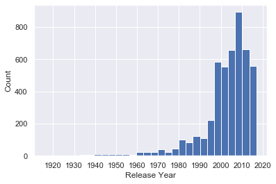

```python
movies['year'].hist(bins=30)
plt.xlabel('Release Year')
plt.ylabel('Count')
plt.xticks(range(1920,2021,10))
plt.show()
```

## Missing Data

```python
#vars with missing data
missing[missing['Percent_missing']>0]
```

|  | Total_missing | Percent_missing |
| --- | --- | --- |
| homepage | 3091 | 64.355611 |
| tagline | 844 | 17.572351 |
| director | 30 | 0.624610 |
| overview | 3 | 0.062461 |
| runtime | 2 | 0.041641 |
| year | 1 | 0.020820 |

## Outlier

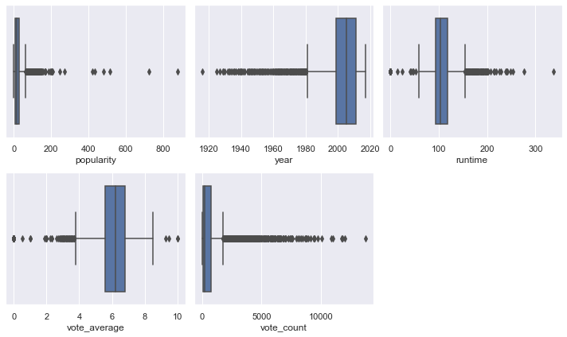

```python
plt.figure(figsize=(10,6))
for i in range(len(num)):
    plt.subplot(2,3,i+1)
    sns.boxplot(movies0[num[i]])
plt.tight_layout()
plt.show()
```

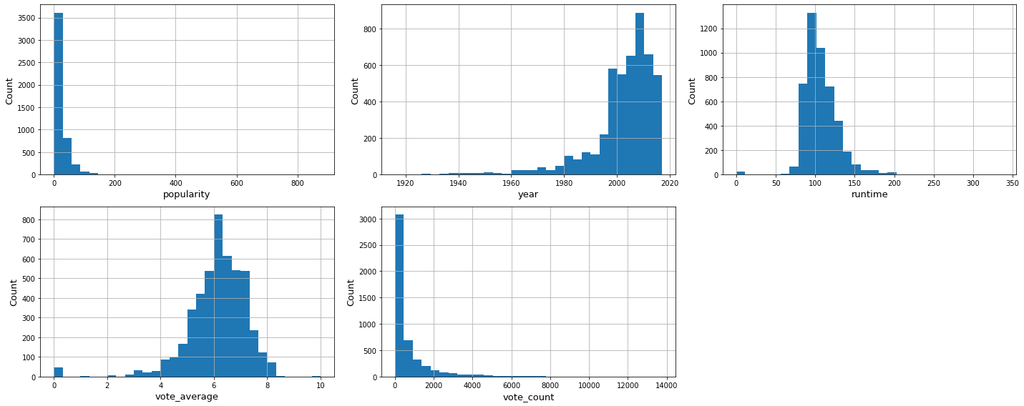

```python
plt.figure(figsize=(20,8))
for i in range(len(num)):
    plt.subplot(2,3,i+1)
    movies0[num[i]].hist(bins=30)
    plt.xlabel(num[i], fontsize=13)
    plt.ylabel('Count', fontsize=13)
plt.tight_layout()
plt.show()
```

```python
movies2.info()
```

```
<class 'pandas.core.frame.DataFrame'>
Index: 4741 entries, Avatar to My Date with Drew
Data columns (total 10 columns):
genres          4741 non-null object
keywords        4741 non-null object
overview        4741 non-null object
popularity      4741 non-null float64
year            4741 non-null float64
runtime         4741 non-null float64
vote_average    4741 non-null float64
vote_count      4741 non-null int64
cast            4741 non-null object
director        4741 non-null object
dtypes: float64(4), int64(1), object(5)
memory usage: 407.4+ KB
```

# Exploratory Data Analysis

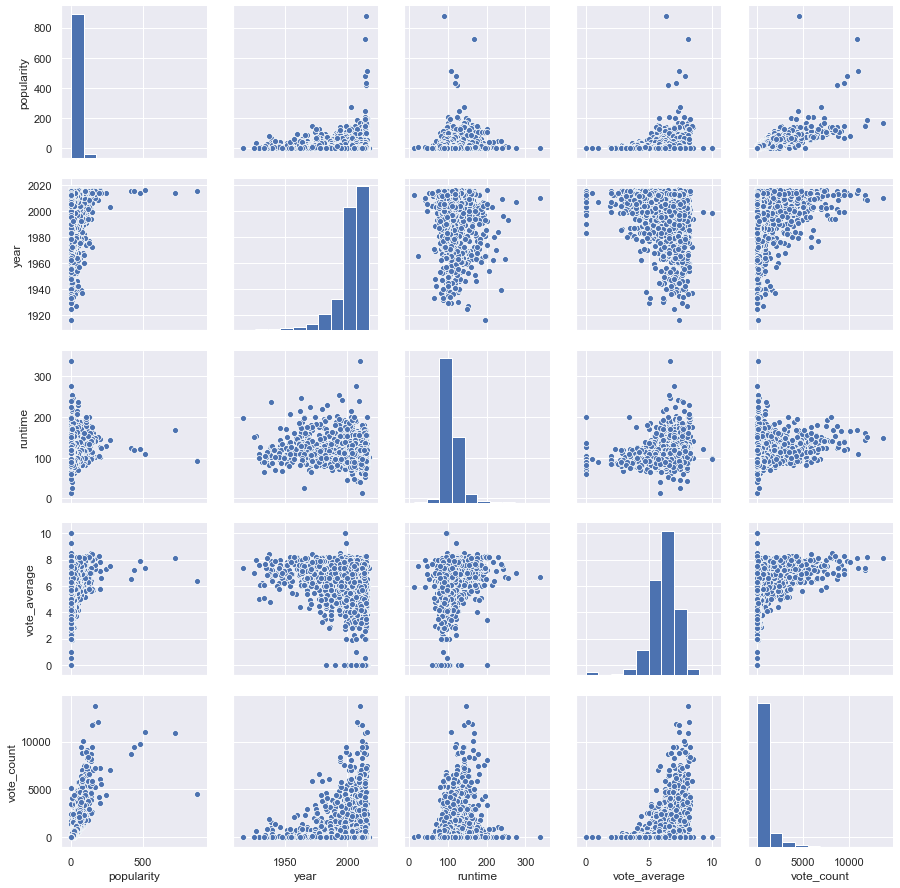

```python
sns.pairplot(movies2)
plt.show()
```

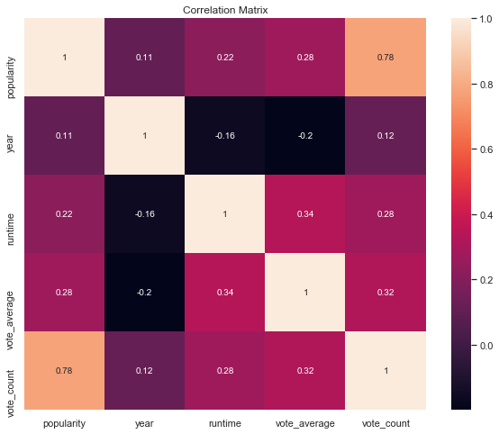

```python
plt.figure(figsize=(10,8))
sns.heatmap(movies2.corr(), annot=True)
plt.title('Correlation Matrix')
plt.show()
```

## Genres

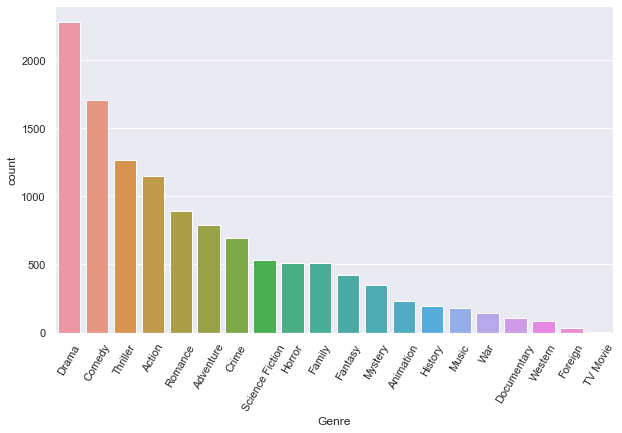

```python
plt.figure(figsize=(10,6))
sns.countplot(all_genre['genre'], order=(all_genre['genre'].value_counts().index))
plt.xlabel('Genre')
plt.xticks(rotation=60)
plt.show()
```

## Keywords

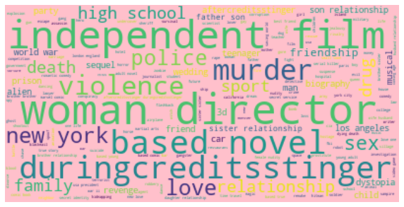

```python
all_keywords = pd.DataFrame(all3, columns=['keyword'])
from wordcloud import WordCloud
wordcloud = WordCloud(background_color="pink").generate(" ".join(all_keywords['keyword']))

plt.figure(figsize=(10,6))
plt.imshow(wordcloud, interpolation='bilinear')
plt.axis("off")
plt.show()
```

## Overview

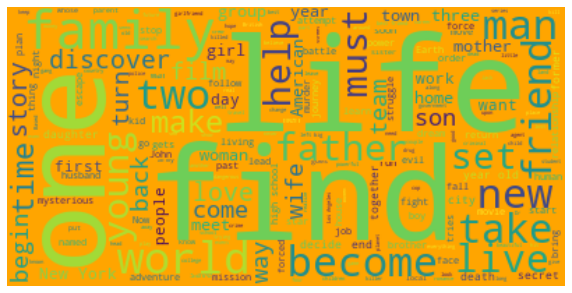

```python
all_words = pd.DataFrame(all3, columns=['word'])
from wordcloud import WordCloud
wordcloud = WordCloud(background_color="orange").generate(" ".join(all_words['word']))

plt.figure(figsize=(10,6))
plt.imshow(wordcloud, interpolation='bilinear')
plt.axis("off")
plt.show()
```

## Cast

```python
print('Top 10 Cast')
all_cast['cast'].value_counts().head(10)
```

```
Top 10 Cast
```

```
Robert De Niro       41
Bruce Willis         34
Matt Damon           33
Nicolas Cage         32
Denzel Washington    29
Brad Pitt            29
Johnny Depp          29
Eddie Murphy         27
Samuel L. Jackson    27
John Travolta        27
Name: cast, dtype: int64
```

## Director

```python
print('Top 10 Directors')
movies2['director'].value_counts().head(10)
```

```
Top 10 Directors
```

```
Steven Spielberg     27
Woody Allen          21
Clint Eastwood       20
Martin Scorsese      19
Ridley Scott         16
Robert Rodriguez     15
Tim Burton           14
Renny Harlin         14
Steven Soderbergh    14
Ron Howard           13
Name: director, dtype: int64
```

# Feature Engineering

10 Features include:

- Categorical (4): Genres, Keywords, Cast, and Director
- Natrual Lauanguage (1): Overview
- Numeric (5): Popularity, Year, Runtime, Vote Count and Vote Average

## Genres, Keywords, Cast, Director

- MultiLabelBinarizer/get_dummies to dummy variables

## Overview

- TFIDF

```python
movies4.shape
```

```
(4741, 23504)
```

## Dimensionality reduction with PCA

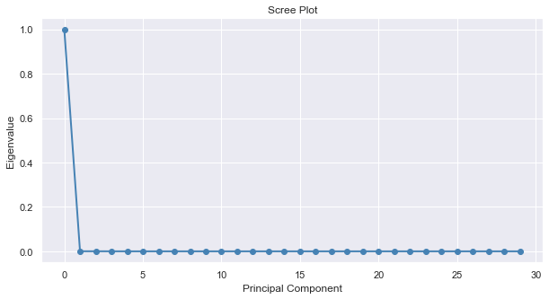

```python
pca = PCA(n_components=30)
pca_components = pca.fit_transform(movies4)

fig = plt.figure(figsize=(10,5))
sing_vals = np.arange(0, pca.n_components_, 1)
eigvals = pca.explained_variance_ratio_
plt.plot(sing_vals, eigvals, 'ro-', linewidth=2, color='steelblue')
plt.title('Scree Plot')
plt.xlabel('Principal Component')
plt.ylabel('Eigenvalue')
plt.show()
```

```python
pca_movies = pd.DataFrame(pca_components, index=movies4.index)
movies_final = pca_movies.iloc[:,:1]
movies_final.head()
```

| original_title | 0 |
| --- | --- |
| Avatar | 11101.288442 |
| Pirates of the Caribbean: At World's End | 3802.636008 |
| Spectre | 3767.921205 |
| The Dark Knight Rises | 8407.113084 |
| John Carter | 1425.069833 |

```python
movies_final.shape
```

```
(4741, 1)
```

# Building Algorithms

According to [Big Five personality traits](https://en.wikipedia.org/wiki/Big_Five_personality_traits), there are five factors about personality which are represented by 'OCEAN'.

- Openness to experience (inventive/curious vs. consistent/cautious)
- Conscientiousness (efficient/organized vs. easy-going/careless)
- Extraversion (outgoing/energetic vs. solitary/reserved)
- Agreeableness (friendly/compassionate vs. challenging/detached)
- Neuroticism (sensitive/nervous vs. secure/confident)

Three clustering algorithms are evaluated and compared based on similarity, consistency and visualization.

## Similarity

Since there is no existing labels in the dataset, Silhouette coefficient was used to measure similarity.

### K-Means Clustering

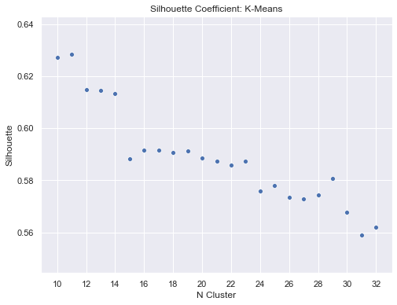

```python
plt.figure(figsize=(8,6))
sns.scatterplot(x='N_Cluster', y='Silhouette', data=result_k)
plt.title('Silhouette Coefficient: K-Means')
plt.xlabel('N Cluster')
plt.xticks(np.arange(10,34,2))
plt.show()
```

### Hierarchical Clustering

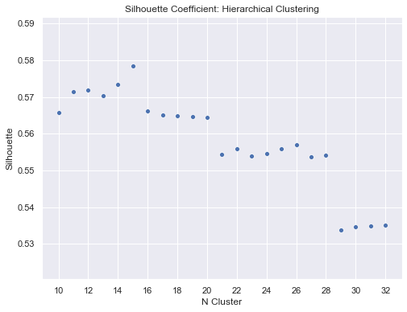

```python
plt.figure(figsize=(8,6))
sns.scatterplot(x='N_Cluster', y='Silhouette', data=result_h)
plt.title('Silhouette Coefficient: Hierarchical Clustering')
plt.xlabel('N Cluster')
plt.xticks(np.arange(10,34,2))
plt.show()
```

### GMM

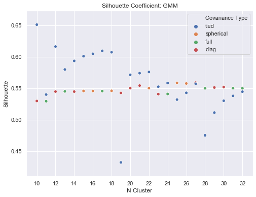

```python
plt.figure(figsize=(8,6))
sns.scatterplot(x='N_Cluster', y='Silhouette', hue='Covariance Type', data=result_g)
plt.title('Silhouette Coefficient: GMM')
plt.xlabel('N Cluster')
plt.xticks(np.arange(10,34,2))
plt.show()
```

## Consistency

To assess consistency of clustering, I followed the steps:

1. Randomly select 25% movies from the final dataset
2. Split the rest of movies (75%) into two halves
3. Put those 25% movies into both samples
4. Evaluate consistency of clustering for those common movies

```python
#summarize results
Algorithm = ['K-Means', 'Hierarchical', 'GMM']

data = {'N_Cluster'  : Ncluster,
        'Silhouette' : Silhouette,
        'Avg_IOU'    : Avg_IOU}

summary = pd.DataFrame(data=data, index=Algorithm)
summary
```

|  | N_Cluster | Silhouette | Avg_IOU |
| --- | --- | --- | --- |
| K-Means | 11.0 | 0.63 | 0.05 |
| Hierarchical | 15.0 | 0.58 | 0.05 |
| GMM | 10.0 | 0.65 | 0.08 |

## Visualization of Clustering

### Dimensionality Reduction Methods

- PCA
- T-SNE
- UMAP

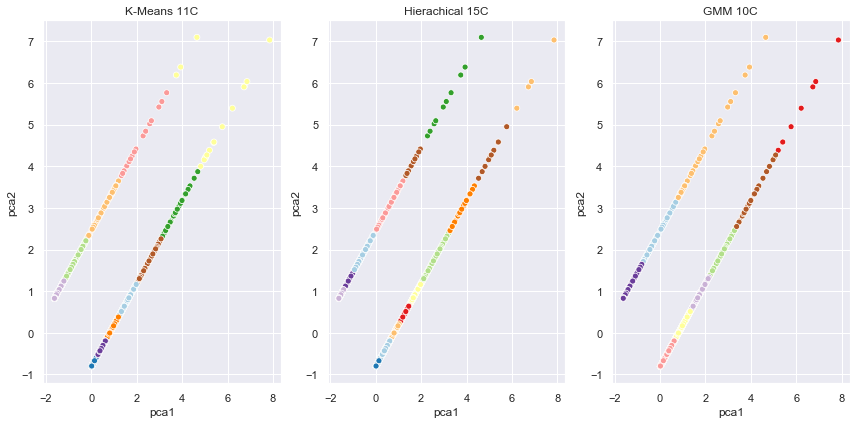

```python
plt.figure(figsize=(12,6))
plt.subplot(131)
sns.scatterplot(x='pca1', y='pca2', hue='kclust11', data=ypred, palette='Paired', legend=False)
plt.title('K-Means 11C')
plt.subplot(132)
sns.scatterplot(x='pca1', y='pca2', hue='hclust15', data=ypred, palette='Paired', legend=False)
plt.title('Hierachical 15C')
plt.subplot(133)
sns.scatterplot(x='pca1', y='pca2', hue='gclust10', data=ypred, palette='Paired', legend=False)
plt.title('GMM 10C')
plt.tight_layout()
plt.show()
```

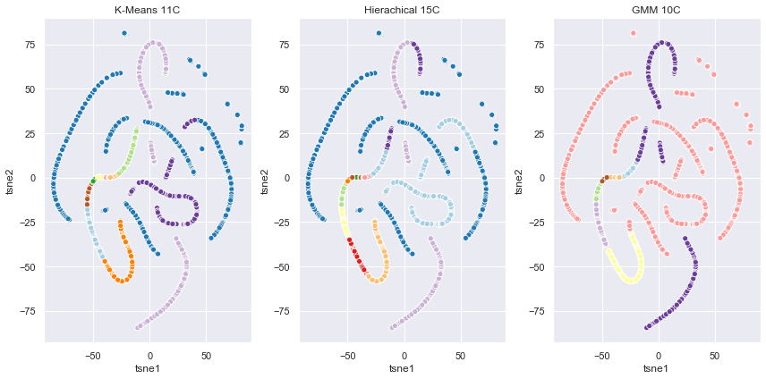

```python
plt.figure(figsize=(12,6))
plt.subplot(131)
sns.scatterplot(x='tsne1', y='tsne2', hue='kclust11', data=ypred, palette='Paired', legend=False)
plt.title('K-Means 11C')
plt.subplot(132)
sns.scatterplot(x='tsne1', y='tsne2', hue='hclust15', data=ypred, palette='Paired', legend=False)
plt.title('Hierachical 15C')
plt.subplot(133)
sns.scatterplot(x='tsne1', y='tsne2', hue='gclust10', data=ypred, palette='Paired', legend=False)
plt.title('GMM 10C')
plt.tight_layout()
plt.show()
```

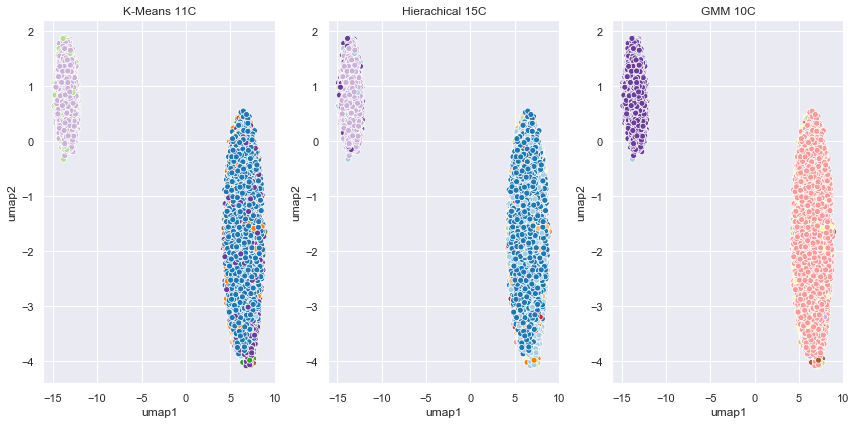

```python
plt.figure(figsize=(12,6))
plt.subplot(131)
sns.scatterplot(x='umap1', y='umap2', hue='kclust11', data=ypred, palette='Paired', legend=False)
plt.title('K-Means 11C')
plt.subplot(132)
sns.scatterplot(x='umap1', y='umap2', hue='hclust15', data=ypred, palette='Paired', legend=False)
plt.title('Hierachical 15C')
plt.subplot(133)
sns.scatterplot(x='umap1', y='umap2', hue='gclust10', data=ypred, palette='Paired', legend=False)
plt.title('GMM 10C')
plt.tight_layout()
plt.show()
```

# Recommendation Engine

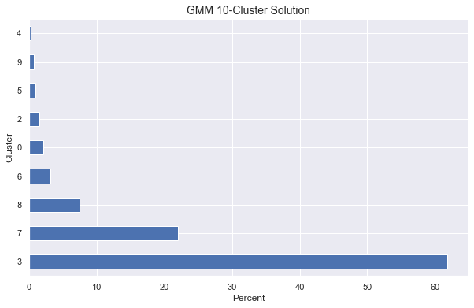

```python
cluster = (ypred['gclust10'].value_counts(normalize=True).rename('Percent').mul(100))
plt.figure(figsize=(10,6))
cluster.plot(kind='barh')
plt.xlabel('Percent')
plt.ylabel('Cluster')
plt.title('GMM 10-Cluster Solution', fontsize=14)
plt.show()
```

```python
find_similar_movies('Inception')
```

```
There are 8 movies you might like. Here are the Top 8.
```

|  | original_title | genres | popularity | year | runtime | vote_average | vote_count | cast | director | Cluster |
| --- | --- | --- | --- | --- | --- | --- | --- | --- | --- | --- |
| 0 | Inception | [Action, Thriller, Science Fiction, Mystery, Adventure] | 167.583710 | 2010.0 | 148.0 | 8.1 | 13752 | [Leonardo DiCaprio, Joseph Gordon-Levitt] | Christopher Nolan | 4 |
| 1 | Interstellar | [Adventure, Drama, Science Fiction] | 724.247784 | 2014.0 | 169.0 | 8.1 | 10867 | [Matthew McConaughey, Jessica Chastain] | Christopher Nolan | 4 |
| 2 | Mad Max: Fury Road | [Action, Adventure, Science Fiction, Thriller] | 434.278564 | 2015.0 | 120.0 | 7.2 | 9427 | [Tom Hardy, Charlize Theron] | George Miller | 4 |
| 3 | The Dark Knight | [Drama, Action, Crime, Thriller] | 187.322927 | 2008.0 | 152.0 | 8.2 | 12002 | [Christian Bale, Heath Ledger] | Christopher Nolan | 4 |
| 4 | Avatar | [Action, Adventure, Fantasy, Science Fiction] | 150.437577 | 2009.0 | 162.0 | 7.2 | 11800 | [Sam Worthington, Zoe Saldana] | James Cameron | 4 |
| 5 | The Avengers | [Science Fiction, Action, Adventure] | 144.448633 | 2012.0 | 143.0 | 7.4 | 11776 | [Robert Downey Jr., Chris Evans] | Joss Whedon | 4 |
| 6 | The Dark Knight Rises | [Action, Crime, Drama, Thriller] | 112.312950 | 2012.0 | 165.0 | 7.6 | 9106 | [Christian Bale, Michael Caine] | Christopher Nolan | 4 |
| 7 | Django Unchained | [Drama, Western] | 82.121691 | 2012.0 | 165.0 | 7.8 | 10099 | [Jamie Foxx, Christoph Waltz] | Quentin Tarantino | 4 |
| 8 | The Hunger Games | [Science Fiction, Adventure, Fantasy] | 68.550698 | 2012.0 | 142.0 | 6.9 | 9455 | [Jennifer Lawrence, Josh Hutcherson] | Gary Ross | 4 |

```python
find_similar_movies('Titanic')
```

```
There are 35 movies you might like. Here are the Top 10.
```

|  | original_title | genres | popularity | year | runtime | vote_average | vote_count | cast | director | Cluster |
| --- | --- | --- | --- | --- | --- | --- | --- | --- | --- | --- |
| 0 | Titanic | [Drama, Romance, Thriller] | 100.025899 | 1997.0 | 194.0 | 7.5 | 7562 | [Kate Winslet, Leonardo DiCaprio] | James Cameron | 9 |
| 1 | Pirates of the Caribbean: The Curse of the Black Pearl | [Adventure, Fantasy, Action] | 271.972889 | 2003.0 | 143.0 | 7.5 | 6985 | [Johnny Depp, Geoffrey Rush] | Gore Verbinski | 9 |
| 2 | Big Hero 6 | [Adventure, Family, Animation, Action, Comedy] | 203.734590 | 2014.0 | 102.0 | 7.8 | 6135 | [Scott Adsit, Ryan Potter] | Chris Williams | 9 |
| 3 | Captain America: Civil War | [Adventure, Action, Science Fiction] | 198.372395 | 2016.0 | 147.0 | 7.1 | 7241 | [Chris Evans, Robert Downey Jr.] | Anthony Russo | 9 |
| 4 | The Martian | [Drama, Adventure, Science Fiction] | 167.932870 | 2015.0 | 141.0 | 7.6 | 7268 | [Matt Damon, Jessica Chastain] | Ridley Scott | 9 |
| 5 | Batman v Superman: Dawn of Justice | [Action, Adventure, Fantasy] | 155.790452 | 2016.0 | 151.0 | 5.7 | 7004 | [Ben Affleck, Henry Cavill] | Zack Snyder | 9 |
| 6 | The Godfather | [Drama, Crime] | 143.659698 | 1972.0 | 175.0 | 8.4 | 5893 | [Marlon Brando, Al Pacino] | Francis Ford Coppola | 9 |
| 7 | Gone Girl | [Mystery, Thriller, Drama] | 143.041543 | 2014.0 | 145.0 | 7.9 | 5862 | [Ben Affleck, Rosamund Pike] | David Fincher | 9 |
| 8 | Forrest Gump | [Comedy, Drama, Romance] | 138.133331 | 1994.0 | 142.0 | 8.2 | 7927 | [Tom Hanks, Robin Wright] | Robert Zemeckis | 9 |
| 9 | The Lord of the Rings: The Fellowship of the Ring | [Adventure, Fantasy, Action] | 138.049577 | 2001.0 | 178.0 | 8.0 | 8705 | [Elijah Wood, Ian McKellen] | Peter Jackson | 9 |
| 10 | The Shawshank Redemption | [Drama, Crime] | 136.747729 | 1994.0 | 142.0 | 8.5 | 8205 | [Tim Robbins, Morgan Freeman] | Frank Darabont | 9 |

# Summary

- Used multiple clustering algorithms to unpack the underlying pattern of movie data
- Grouped 4K+ movies into 10-15 clusters based on their characteristics
- Evaluated performance of algorithms from various perspectives
- Built a recommendation engine based on the GMM 10-cluster solution

# Future Work

- Incorperate individual user rating data and build collaborative filtering system
- Make the engine more powerful not only considering movie characteristics but also user opinions